# CTA-ED Exercise 4: Scaling techniques (with correct answers)

Junke Guan

6/03/2024

# Introduction

The hands-on exercise for this week focuses on: 1) scaling texts ; 2) implementing scaling techniques using `quanteda`.

In this tutorial, you will learn how to:

- Scale texts using the “wordfish” algorithm
- Scale texts gathered from online sources
- Replicate analyses by @kaneko_estimating_2021

Before proceeding, we’ll load the packages we will need for this tutorial.

```r
library(dplyr)
library(quanteda) # includes functions to implement Lexicoder
library(quanteda.textmodels) # for estimating similarity and complexity measures
library(quanteda.textplots) #for visualizing text modelling results
```

In this exercise we’ll be using the dataset we used for the sentiment analysis exercise. The data were collected from the Twitter accounts of the top eight newspapers in the UK by circulation. The tweets include any tweets by the news outlet from their main account.

## Importing data

If you’re working on this document from your own computer (“locally”) you can download the tweets data in the following way:

```r
tweets  <- readRDS(gzcon(url("https://github.com/cjbarrie/CTA-ED/blob/main/data/sentanalysis/newstweets.rds?raw=true")))
```

We first take a sample from these data to speed up the runtime of some of the analyses.

```r
tweets <- tweets %>%
  sample_n(20000)
```

## Construct `dfm` object

Then, as in the previous exercise, we create a corpus object, specify the document-level variables by which we want to group, and generate our document feature matrix.

```r
#make corpus object, specifying tweet as text field
tweets_corpus <- corpus(tweets, text_field = "text")

#add in username document-level information
docvars(tweets_corpus, "newspaper") <- tweets$user_username

dfm_tweets <- dfm(tokens(tweets_corpus,
                    remove_punct = TRUE)) %>%
  dfm_select(pattern = stopwords("english"),
             selection = "remove",
             valuetype = "fixed")
```

We can then have a look at the number of documents (tweets) we have per newspaper Twitter account.

```r
## number of tweets per newspaper
table(docvars(dfm_tweets, "newspaper"))
```

```
##
##     DailyMailUK     DailyMirror EveningStandard        guardian         MetroUK
##            2131            5875            2102            2876             953
##       Telegraph          TheSun        thetimes
##            1493            3903             667
```

```r
dfm_tweets
```

```
## Document-feature matrix of: 20,000 documents, 49,090 features (99.98% sparse) and 31 docvars.
##        features
## docs    rt @mirrorparents tv presenter scared daughter four-year-old makes
##   text1  1              1  1         1      1        1             1     1
##   text2  0              0  0         0      0        0             0     0
##   text3  0              0  0         0      0        0             0     0
##   text4  1              0  0         0      0        0             0     0
##   text5  0              0  0         0      0        0             0     0
##   text6  0              0  0         0      0        0             0     0
##        features
## docs    chilling comment
##   text1        1       1
##   text2        0       0
##   text3        0       0
##   text4        0       0
##   text5        0       0
##   text6        0       0
## [ reached max_ndoc ... 19,994 more documents, reached max_nfeat ... 49,080 more features ]
```

## Estimate wordfish model

Once we have our data in this format, we are able to group and trim the document feature matrix before estimating the wordfish model.

```r
# compress the document-feature matrix at the newspaper level
dfm_newstweets <- dfm_group(dfm_tweets, groups = newspaper)

# remove words not used by two or more newspapers
dfm_newstweets <- dfm_trim(dfm_newstweets,
                                min_docfreq = 2, docfreq_type = "count")

## size of the document-feature matrix
dim(dfm_newstweets)
```

```
## [1]     8 11132
```

```r
#### estimate the Wordfish model ####
set.seed(123L)
dfm_newstweets_results <- textmodel_wordfish(dfm_newstweets)
```

And this is what results.

```r
summary(dfm_newstweets_results)
```

```
##
## Call:
## textmodel_wordfish.dfm(x = dfm_newstweets)
##
## Estimated Document Positions:
##                   theta       se
## DailyMailUK      0.7175 0.012038
## DailyMirror      1.1606 0.006464
## EveningStandard -0.2193 0.015980
## guardian        -0.9857 0.011019
## MetroUK         -0.0196 0.022878
## Telegraph       -1.0193 0.012116
## TheSun           1.4102 0.006183
## thetimes        -1.0444 0.016063
##
## Estimated Feature Scores:
##          rt     tv presenter scared daughter four-year-old makes chilling
## beta 0.4726 0.2421   -0.1013 0.5449   0.8785         1.526 0.355    1.381
## psi  5.3492 2.2708    0.5561 0.2284   2.2905        -1.811 2.205    1.004
##      comment family  death     row victim    want  spared electric   chair
## beta   0.364 0.2751 0.1819 0.03692  0.473 -0.2455  0.8214  -0.1402  0.8375
## psi    1.031 3.4508 3.7513 2.19459  1.771  2.5577 -0.0194   0.3606 -0.4702
##        it’s     got    come  heart #oscars     say ripped  apart  woman     21
## beta -0.749 0.01174 -0.4673 0.1792 -0.2126 -0.1778 0.7963 0.6247 0.8261 0.3145
## psi   2.489 2.56023  2.4154 2.0115  0.8591  2.9301 0.0045 0.9384 3.1293 1.0958
##       found stabbed   house
## beta 0.3553  0.6257 0.06925
## psi  2.9617  1.8039 2.75681
```

We can then plot our estimates of the $\theta$s—i.e., the estimates of the latent newspaper position—as so.

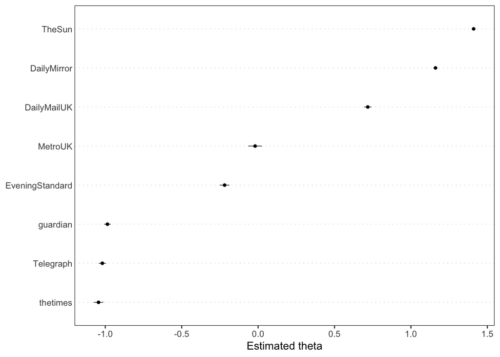

```r
textplot_scale1d(dfm_newstweets_results)
```

Interestingly, we seem not to have captured ideology but some other tonal dimension. We see that the tabloid newspapers are scored similarly, and grouped toward the right hand side of this latent dimension; whereas the broadsheet newspapers have an estimated theta further to the left.

Plotting the “features,” i.e., the word-level betas shows how words are positioned along this dimension, and which words help discriminate between news outlets.

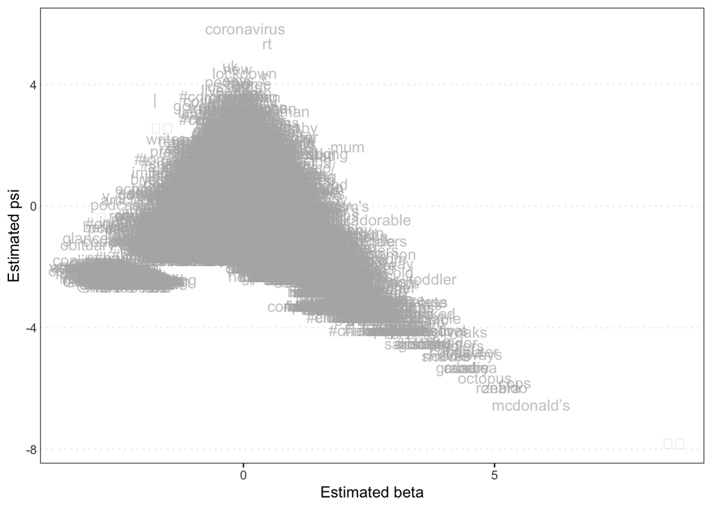

```r
textplot_scale1d(dfm_newstweets_results, margin = "features")
```

And we can also look at these features.

```r
features <- dfm_newstweets_results[["features"]]

betas <- dfm_newstweets_results[["beta"]]

feat_betas <- as.data.frame(cbind(features, betas))
feat_betas$betas <- as.numeric(feat_betas$betas)

feat_betas %>%
  arrange(desc(betas)) %>%
  top_n(20) %>%
  kbl() %>%
  kable_styling(bootstrap_options = "striped")
```

| features | betas |
| --- | --- |
| 🎥 | 8.574706 |
| mcdonald’s | 5.726584 |
| cops | 5.405091 |
| ronaldo | 5.141564 |
| zebra | 5.141564 |
| octopus | 4.808542 |
| sideways | 4.523231 |
| lad | 4.441774 |
| grandma | 4.441774 |
| crosby | 4.441774 |
| aussie | 4.441774 |
| commuter | 4.391793 |
| koala | 4.391793 |
| toddlers | 4.244066 |
| toys | 4.193536 |
| #hollyoaks | 4.131199 |
| labrador | 4.093610 |
| noodle | 4.034627 |
| shaves | 4.034627 |
| pic | 3.880110 |

## Replicating Kaneko et al.

This section adapts code from the replication data provided for @kaneko_estimating_2021 [here](https://dataverse.harvard.edu/dataset.xhtml?persistentId=doi:10.7910/DVN/EL3KYD).

If you’re working locally, you can download the `dfm` data with:

```r
kaneko_dfm  <- readRDS(gzcon(url("https://github.com/cjbarrie/CTA-ED/blob/main/data/wordscaling/study1_kaneko.rds?raw=true")))
```

This data is in the form a document-feature-matrix. We can first manipulate it in the same way as @kaneko_estimating_2021 by grouping at the level of newspaper and removing infrequent words.

```r
table(docvars(kaneko_dfm, "Newspaper"))
```

```
##
##       Asahi     Chugoku    Chunichi    Hokkaido      Kahoku    Mainichi
##          38          24          47          46          18          26
##      Nikkei Nishinippon      Sankei     Yomiuri
##          13          27          14          30
```

```r
## prepare the newspaper-level document-feature matrix
# compress the document-feature matrix at the newspaper level
kaneko_dfm_study1 <- dfm_group(kaneko_dfm, groups = Newspaper)
# remove words not used by two or more newspapers
kaneko_dfm_study1 <- dfm_trim(kaneko_dfm_study1, min_docfreq = 2, docfreq_type = "count")

## size of the document-feature matrix
dim(kaneko_dfm_study1)
```

```
## [1]   10 4660
```

## Exercises

1. Estimate a wordfish model for with Kaneko (2021)’s data

```r
## estimate the Wordfish model
set.seed(123)
kaneko_wordfish <- textmodel_wordfish(kaneko_dfm_study1)
summary(kaneko_wordfish)
```

```
##
## Call:
## textmodel_wordfish.dfm(x = kaneko_dfm_study1)
##
## Estimated Document Positions:
##               theta      se
## Asahi       -0.9892 0.01651
## Chugoku     -0.4585 0.02446
## Chunichi    -1.2230 0.01232
## Hokkaido    -0.4160 0.01917
## Kahoku      -0.5731 0.02753
## Mainichi    -0.1876 0.02546
## Nikkei       1.2578 0.04403
## Nishinippon -0.2616 0.02750
## Sankei       1.2472 0.03943
## Yomiuri      1.6040 0.02477
##
## Estimated Feature Scores:
##        安保    法制    国会     一線   越え 安倍内閣  新た 安全保障政策
## beta 0.2157 0.01591 0.09476 -0.05989 -1.362  -1.6217 0.332    -0.006181
## psi  3.6911 3.36064 3.73441 -0.18786 -1.989   0.4758 2.192     0.789972
##      関連法案    閣議    決定   提出 安倍首相    先月     米    議会     演説
## beta  0.01405 -0.1579 -0.2177 0.5569   0.2524 -0.6656 0.5448 -0.9467 -0.22245
## psi   2.41503  0.7228  1.2414 2.5076   2.5758 -0.5345 2.8280  0.5425 -0.08278
##      安全保障    戦後   初めて 大改革      夏   成就    約束    通り   合意
## beta   0.2303 -0.3609 0.003823 -1.362 -0.6648 -2.335 -0.6655 -0.4473 0.4545
## psi    3.0372  2.0478 0.937039 -1.989  0.6898 -2.481  0.1587  0.4404 1.8744
##      歴史的  転換 集団的自衛権    行使
## beta -1.154 0.141       0.2183 0.05474
## psi  -2.105 1.609       3.7932 3.73714
```

The Wordfish model estimates the latent positions of Japanese newspapers based on the language used in their editorial texts. The results show that the newspapers are distributed along a single dimension represented by the theta parameter. Newspapers with similar language use are positioned closer together, while those using different vocabulary are placed further apart on the scale.

From the results, some newspapers such as Nikkei, Sankei, and Yomiuri have positive theta values and appear on the right side of the scale, while others such as Asahi, Chunichi, and Kahoku have negative theta values and are positioned on the left side. This suggests that these groups of newspapers differ systematically in their language use.

Although the model does not directly label the dimension, it likely reflects differences in editorial tone, style, or possibly political orientation across newspapers. Overall, the results indicate that the Wordfish model is able to capture meaningful variation in how different newspapers frame their editorial content.

2. Visualize the results

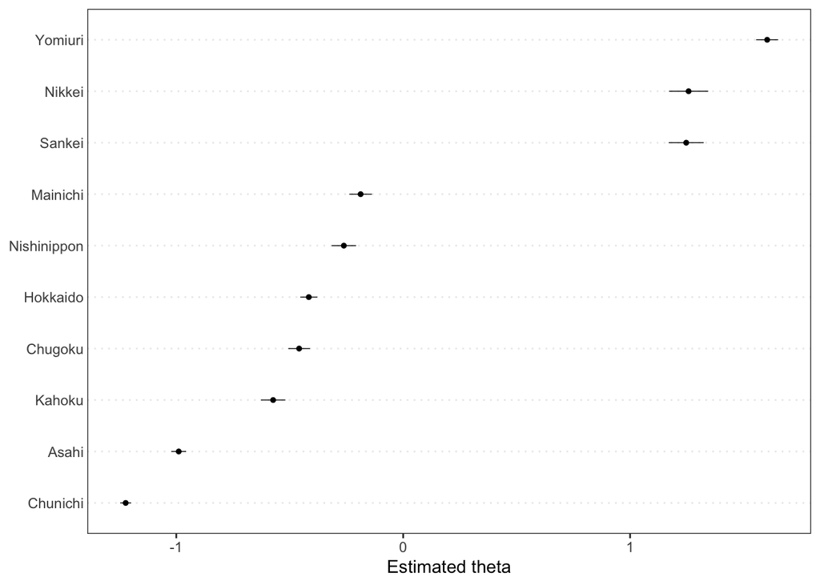

Wordfish model estimates of Japanese newspapers’ editorial texts

```r
## We can then plot our estimates of the thetas---i.e., the estimates of the latent Japanese newspaper position.
textplot_scale1d(kaneko_wordfish)
```

The plot visualizes the estimated positions of Japanese newspapers along the latent dimension identified by the Wordfish model. Newspapers that appear closer together on the scale use more similar language in their editorial texts, while those further apart show greater differences in vocabulary.

From the plot, newspapers such as Yomiuri, Nikkei, and Sankei appear on the right side of the scale with relatively high theta values. In contrast, newspapers such as Asahi, Chunichi, and Kahoku are positioned on the left side with lower theta values. This indicates that these newspapers differ systematically in their language use.

Although the model does not explicitly label the dimension, the separation between newspapers likely reflects differences in editorial style, tone, or possibly ideological orientation. Overall, the visualization helps illustrate how the Wordfish model captures meaningful variation in the way newspapers frame their editorial content.